# CCHS Ontario population for microsimulations

Hana Fu

02 February, 2022

# 1 Sample and bootstrap weights

Histogram display the sum of each 500 bootstrap weights, with **blue** line indicates the sum of sample weights (=11,682,113). This is to check whether bootstrap weights already include the sample weights, which seem to be true.

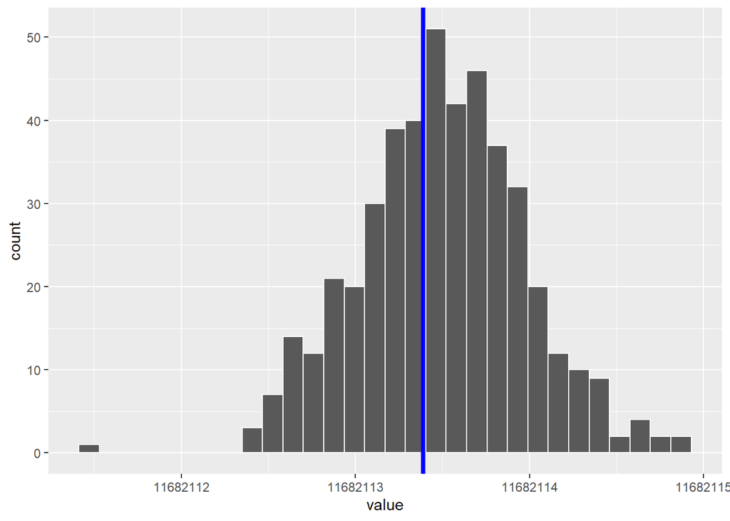

```r
cchs2013_14_Ontario$sex <- factor(cchs2013_14_Ontario$DHH_SEX, labels=c("Male","Female"))

cchs2013_14_Ontario$agecat <- cut(cchs2013_14_Ontario$DHH_AGE, c(12,30,40,50,60,70,80,105),
                                  include.lowest = TRUE, right = FALSE)
levels(cchs2013_14_Ontario$agecat) <- c("12-29","30-39","40-49","50-59","60-69","70-79","80+")

cchs2013_14_Ontario$educat <- factor(cchs2013_14_Ontario$EDUDR04,
                                     labels=c("Less than secondary","Secondary school grad",
                                     "Some post-secondary", "Post-secondary grad", "NS"),
                                     levels =c(1,2,3,4,9))

cchs2013_14_Ontario$incpercat <- with(cchs2013_14_Ontario,
                                      ifelse(INCDPER < 10 | INCDPER %in% c(96,99), INCDPER,
                                             ifelse(INCDPER %in% c(10,11), 10,
                                                    ifelse(INCDPER %in% c(12,13), 11,
                                                           ifelse(INCDPER == 14, 12, NA)))))
cchs2013_14_Ontario$incpercat <- factor(cchs2013_14_Ontario$incpercat,
                                        labels = c("No income", "LESS THAN $5,000", "$5,000 TO $9,999", "$10,000 TO $14,999", "$15,000 TO $19,999", "$20,000 TO $29,999", "$30,000 TO $39,999", "$40,000 TO $49,999", "$50,000 TO $59,999", "$60,000 TO $79,999","$80,000 TO 99,999","$100k or more","NS"),
                                        levels =c(1:12,99))

cchs2013_14_Ontario$inchhcat <- with(cchs2013_14_Ontario,
                                      ifelse(INCDHH < 10 | INCDHH %in% c(96,99), INCDHH,
                                             ifelse(INCDHH %in% c(10,11), 10,
                                                    ifelse(INCDHH %in% c(12,13), 11,
                                                           ifelse(INCDHH %in% c(14,15), 12, NA)))))
cchs2013_14_Ontario$inchhcat <- factor(cchs2013_14_Ontario$inchhcat,
                                        labels = c("No income", "LESS THAN $5,000", "$5,000 TO $9,999", "$10,000 TO $14,999", "$15,000 TO $19,999", "$20,000 TO $29,999", "$30,000 TO $39,999", "$40,000 TO $49,999", "$50,000 TO $59,999", "$60,000 TO $79,999","$80,000 TO 99,999","$100k or more","NS"),
                                        levels =c(1:12,99))

cchs2013_14_Ontario$ethncat <- factor(cchs2013_14_Ontario$SDCDCGT,
                                      labels = c('White','Black','Korean','Filipino','Japanese','Chinese','South Asian','South East Asian','Arab','West Asian','Latin American','Other Racial or Cultural Origin','Multiple Racial/Cultural Origins','NA','NS'),
                                      levels = c(1:13,96,99))

cchs2013_14_Ontario$maritalcat <- factor(cchs2013_14_Ontario$DHH_MS,
  labels = c('Married','Common-Law','Widowed','Separated','Divorced','Single/Never Married','DK','Refusal','NS'),
  levels = c(1:6,97,98,99))

cchs2013_14_Ontario$geourcat <- factor(cchs2013_14_Ontario$GEODUR2,
       labels=c("Population Centre", "Rural"),
       levels=c(1,2))

cchs2013_14_Ontario$alcfreqcat <- factor(cchs2013_14_Ontario$ALC_2,
                                         labels = c('less than once a month','once a month','2 to 3 times a month','once a week','2 to 3 times a week','4 to 6 times a week','every day','NA','DK','Refusal','NS'),
                                         levels = c(1:7,96:99))

cchs2013_14_Ontario$alctypecat <- factor(cchs2013_14_Ontario$ALCDTTM,
                                         labels = c("Regular drinker","Occasional drinker","Did not drink in the last 12 months","NS"),
                                         levels = c(1,2,3,9))

cchs2013_14_Ontario$alchvycat <- with(cchs2013_14_Ontario,
                                      ifelse(ALC_3 %in% 1:2, 2, # 1 is heavy drinking
                                        ifelse(ALC_3 %in% 3:6, 1, # 2 did not have heaving drinking
                                               ifelse(ALC_3 %in% 96:99, ALC_3, NA))))

cchs2013_14_Ontario$alchvycat <- factor(cchs2013_14_Ontario$alchvycat,
                                        labels = c("Heavy drinking in the past year at least once per month","Did not heavy drink in the past year","NA","DK","Refusal","NS"),
                                        levels = c(1:2,96:99))
```

# 2 Tabulation of counts by age and sex (without survey weights)

| Age group | Male | Female | Both |
| --- | --- | --- | --- |
| 12-29 | 4304 | 4464 | 8768 |
| 30-39 | 1865 | 2499 | 4364 |
| 40-49 | 2098 | 2321 | 4419 |
| 50-59 | 2939 | 3627 | 6566 |
| 60-69 | 3351 | 4316 | 7667 |
| 70-79 | 2269 | 3001 | 5270 |
| 80+ | 1136 | 2009 | 3145 |
| Total | 17962 | 22237 | 40199 |

# 3 Tabulation of counts by socioeconomic (without survey weights)

|  | Age group | Sex | Education | Income (personal) | Income (household) | Ethnicity | Marital Status | Urban/Rural | Count |
| --- | --- | --- | --- | --- | --- | --- | --- | --- | --- |
| 1 | 12-29 | Male | Less than secondary | No income | $10,000 TO $14,999 | White | Single/Never Married | Population Centre | 1 |
| 2 | 12-29 | Male | Less than secondary | No income | $10,000 TO $14,999 | Arab | Single/Never Married | Population Centre | 1 |
| 3 | 12-29 | Male | Less than secondary | No income | $10,000 TO $14,999 | Multiple Racial/Cultural Origins | Single/Never Married | Population Centre | 1 |
| 4 | 12-29 | Male | Less than secondary | No income | $40,000 TO $49,999 | White | Single/Never Married | Population Centre | 2 |
| 5 | 12-29 | Male | Less than secondary | No income | $40,000 TO $49,999 | Chinese | Single/Never Married | Population Centre | 1 |
| 6 | 12-29 | Male | Less than secondary | No income | $40,000 TO $49,999 | NA | Single/Never Married | Population Centre | 1 |
| 7 | 12-29 | Male | Less than secondary | No income | $50,000 TO $59,999 | White | Common-Law | Population Centre | 1 |
| 8 | 12-29 | Male | Less than secondary | No income | $50,000 TO $59,999 | Chinese | Single/Never Married | Population Centre | 1 |
| 9 | 12-29 | Male | Less than secondary | No income | $60,000 TO $79,999 | White | Single/Never Married | Rural | 1 |
| 10 | 12-29 | Male | Less than secondary | No income | $80,000 TO 99,999 | White | Single/Never Married | Population Centre | 1 |

[output cut: 14367 more lines]

# 4 Tabulation of counts by alcohol drinking status (without survey weights)

|  | Frequency of drinking alcohol | Type of drinker | Heavy drinking | Count |
| --- | --- | --- | --- | --- |
| 1 | less than once a month | Occasional drinker | Did not heavy drink in the past year | 6913 |
| 2 | less than once a month | Occasional drinker | DK | 10 |
| 3 | less than once a month | Occasional drinker | Refusal | 2 |
| 4 | less than once a month | Occasional drinker | NS | 6 |
| 5 | once a month | Regular drinker | Heavy drinking in the past year at least once per month | 245 |
| 6 | once a month | Regular drinker | Did not heavy drink in the past year | 2776 |
| 7 | once a month | Regular drinker | DK | 5 |
| 8 | once a month | Regular drinker | Refusal | 2 |
| 9 | once a month | Regular drinker | NS | 1 |
| 10 | 2 to 3 times a month | Regular drinker | Heavy drinking in the past year at least once per month | 762 |

[output cut: 33 more lines]

# 5 Implement survey design

```r
# See link for instructions https://stackoverflow.com/questions/45642026/survey-weights-and-boostrap-wieghts-to-get-counts-and-cis

library(survey)
cchsDesign <- svrepdesign(data = cchs2013_14_Ontario,
                        weights = ~WTS_S,
                        repweights = "BSW[0-5]+",
                        type = "bootstrap",
                        combined.weights = TRUE,
                        mse = TRUE)
```

## 5.1 Obtain survey-weighted population size

### 5.1.1 Age and sex

```r
svyTabRes <- svytable(
  ~agecat + sex, # variable to pass to function
  design = cchsDesign # design object
  )
```

| Age group | Male | Female | Both |
| --- | --- | --- | --- |
| 12-29 | 1608879.5 | 1564523.5 | 3173403.0 |
| 30-39 | 840829.2 | 902833.4 | 1743662.6 |
| 40-49 | 964547.6 | 943282.7 | 1907830.3 |
| 50-59 | 978280.6 | 1057266.6 | 2035547.1 |
| 60-69 | 733676.3 | 768463.7 | 1502140.1 |
| 70-79 | 411997.9 | 462613.9 | 874611.8 |
| 80+ | 174552.1 | 270366.5 | 444918.6 |
| Total | 5712763.1 | 5969350.3 | 11682113.4 |

### 5.1.2 Socioeconomic and alcohol drinking status

Here, eight variables are included to generate survey-weighted counts. The eight variables are age, sex, education, household income, ethnicity, marital status, urban/rural setting, and heavy drinking.

```r
svySesAlcTabRes <- svytable(
  ~agecat + sex + educat + inchhcat + ethncat + maritalcat + geourcat + alchvycat, # variable to pass to function
  design = cchsDesign # design object
  )
```

The codes above creates a 8 dimension output in the “svySesAlcTabRes” object. Many of the “slices” contains zeros, here are a couple of examples:

> svySesAlcTabRes[,,“Secondary school grad”,“LESS THAN $5,000”,“Black”,“Married”,“Population Centre”,“Heavy drinking in the past year at least once per month”]

```
##        sex
## agecat  Male Female
##   12-29    0      0
##   30-39    0      0
##   40-49    0      0
##   50-59    0      0
##   60-69    0      0
##   70-79    0      0
##   80+      0      0
```

> svySesAlcTabRes[,,“Less than secondary”,“No income”,“White”,“Single/Never Married”,“Rural”,“Did not heavy drink in the past year”]

```
##        sex
## agecat  Male Female
##   12-29    0      0
##   30-39    0      0
##   40-49    0      0
##   50-59    0      0
##   60-69    0      0
##   70-79    0      0
##   80+      0      0
```

There are also “slices” that are non-zero:

> svySesAlcTabRes[,,“Post-secondary grad”,“$80,000 TO 99,999”,“White”,“Married”,“Population Centre”,“Heavy drinking in the past year at least once per month”]

```
##        sex
## agecat     Male  Female
##   12-29 2009.01 3390.22
##   30-39 5793.60 3327.12
##   40-49 8363.71 2275.35
##   50-59 4869.64 2016.76
##   60-69 2695.14 1192.54
##   70-79  322.26   52.80
##   80+      0.00  168.32
```